# L03_Implementation_Joseph_Armijo_ITAI4374

Module 03 Lab – Exploring Neural Information Processing

Imports

```python
import numpy as np
import matplotlib.pyplot as plt
```

PART 1: BIOLOGICAL NEURON SIMULATION

Biological Neuron Class

```python
class BiologicalNeuron:
    """Simulates simplified biological neuron characteristics"""

    def __init__(self):
        self.resting_potential = -70  # mV
        self.threshold = -55         # mV
        self.peak = 40               # mV (action potential peak)
        self.refractory_period = 5   # time steps
        self.decay_rate = 0.1

    def simulate_response(self, input_current, time_steps=100):
        membrane_potential = self.resting_potential
        membrane_potentials = []
        refractory_counter = 0

        for t in range(time_steps):

            if refractory_counter > 0:
                refractory_counter -= 1
                membrane_potential = self.resting_potential

            else:
                membrane_potential += input_current

                if membrane_potential >= self.threshold:
                    membrane_potential = self.peak
                    refractory_counter = self.refractory_period

                membrane_potential -= self.decay_rate

            membrane_potentials.append(membrane_potential)

        return membrane_potentials
```

Test Different Input Currents

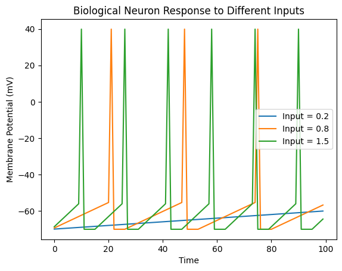

```python
neuron = BiologicalNeuron()

inputs = [0.2, 0.8, 1.5]

plt.figure()

for current in inputs:
    response = neuron.simulate_response(current)
    plt.plot(response, label=f"Input = {current}")

plt.xlabel("Time")
plt.ylabel("Membrane Potential (mV)")
plt.title("Biological Neuron Response to Different Inputs")
plt.legend()
plt.show()
```

## Biological Neuron Response to Different Inputs – Analysis

From the graph, the neuron's behavior clearly depends on the strength of the input current.

- When the input current is **0.2**, the membrane potential slowly increases but never reaches the threshold of -55 mV. Because of this, no action potential is generated.
- When the input current is **0.8**, the neuron occasionally reaches threshold and produces action potentials (spikes up to about 40 mV).
- When the input current is **1.5**, the neuron spikes much more frequently.

This demonstrates the **all-or-none principle**. The neuron does not partially fire — once threshold is reached, a full spike occurs. If threshold is not reached, no spike happens at all.

The graph also shows the effect of the **refractory period**. After each spike, the membrane potential resets near the resting potential (-70 mV), preventing immediate re-firing.

Overall, this shows that biological neurons encode information through **spike frequency**. Stronger input currents produce more frequent action potentials, which is how biological systems transmit information.

PART 2: ARTIFICIAL NEURON

Artificial Neuron Class

```python
class ArtificialNeuron:
    """Implements artificial neuron"""

    def __init__(self, num_inputs):
        self.weights = np.random.randn(num_inputs)
        self.bias = 0

    def activate(self, inputs, activation="sigmoid"):
        weighted_sum = np.dot(self.weights, inputs) + self.bias

        if activation == "sigmoid":
            return 1 / (1 + np.exp(-weighted_sum))

        elif activation == "relu":
            return max(0, weighted_sum)

        elif activation == "tanh":
            return np.tanh(weighted_sum)

        else:
            return weighted_sum
```

Compare Activation Functions

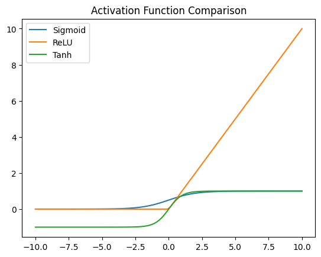

```python
neuron = ArtificialNeuron(1)

x_values = np.linspace(-10, 10, 100)
sigmoid_outputs = []
relu_outputs = []
tanh_outputs = []

for x in x_values:
    sigmoid_outputs.append(1 / (1 + np.exp(-x)))
    relu_outputs.append(max(0, x))
    tanh_outputs.append(np.tanh(x))

plt.figure()
plt.plot(x_values, sigmoid_outputs, label="Sigmoid")
plt.plot(x_values, relu_outputs, label="ReLU")
plt.plot(x_values, tanh_outputs, label="Tanh")

plt.title("Activation Function Comparison")
plt.legend()
plt.show()
```

## Activation Function Comparison – Analysis

From the graph:

- Sigmoid produces a smooth S-shaped curve between 0 and 1.
- ReLU outputs 0 for all negative inputs and increases linearly for positive values.
- Tanh is similar to sigmoid but ranges from -1 to 1 and is centered at zero.

### Key Observations

- ReLU grows much faster than sigmoid or tanh for positive inputs.
- Sigmoid compresses large values into a small range, which can cause vanishing gradient issues in deep networks.
- Tanh provides negative outputs, which often helps learning because it is zero-centered.

Unlike biological neurons, none of these activation functions create a true spike. They produce continuous outputs instead of discrete action potentials.

PART 3: SIMPLE NETWORKS

Simple Feedforward Artificial Network

```python
class SimpleNetwork:
    def __init__(self):
        self.hidden1 = ArtificialNeuron(2)
        self.hidden2 = ArtificialNeuron(2)
        self.output = ArtificialNeuron(2)

    def forward(self, inputs):
        h1 = self.hidden1.activate(inputs)
        h2 = self.hidden2.activate(inputs)

        hidden_outputs = np.array([h1, h2])
        final_output = self.output.activate(hidden_outputs)

        return final_output
```

Test Network with Different Inputs

```python
network = SimpleNetwork()

input_patterns = [
    np.array([0, 0]),
    np.array([0, 1]),
    np.array([1, 0]),
    np.array([1, 1])
]

for pattern in input_patterns:
    output = network.forward(pattern)
    print(f"Input: {pattern} -> Output: {output}")
```

```
Input: [0 0] -> Output: 0.7111226291683825
Input: [0 1] -> Output: 0.7183808922104181
Input: [1 0] -> Output: 0.737870516286676
Input: [1 1] -> Output: 0.7399944146478558
```

### Observations

- The outputs are continuous values between 0 and 1.
- The network responds slightly differently to each input combination.
- There is no timing, no spikes, and no refractory period.
- The network processes information instantly in a single forward pass.

This is very different from biological neurons, which:

- Process information over time
- Encode information in spike frequency
- Have physical constraints like refractory periods

Simple Biological Network (2 neurons)

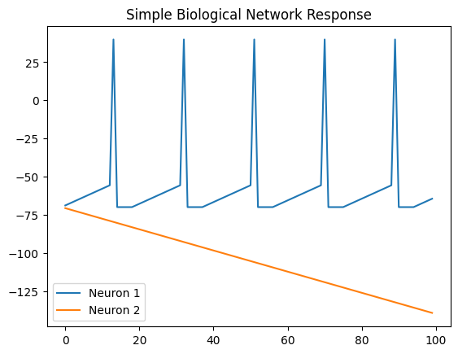

```python
neuron1 = BiologicalNeuron()
neuron2 = BiologicalNeuron()

input_signal = 1.2

response1 = neuron1.simulate_response(input_signal)
response2 = neuron2.simulate_response(np.mean(response1)/100)

plt.figure()
plt.plot(response1, label="Neuron 1")
plt.plot(response2, label="Neuron 2")
plt.title("Simple Biological Network Response")
plt.legend()
plt.show()
```

## Simple Biological Network – Analysis

From the biological network graph:

- Neuron 1 clearly shows repeated action potentials (spikes reaching around 40 mV).
- After each spike, it resets close to the resting potential (around -70 mV).
- The refractory period prevents immediate re-firing.
- Neuron 2 does not spike. Its membrane potential gradually decreases over time.

### Why This Happened

This demonstrates an important biological principle:

If synaptic input is not strong enough, downstream neurons will not fire.

Biological networks depend on:

- Signal strength
- Timing
- Threshold accumulation

# Written Analysis

Joseph Armijo  
Neuroscience as Model for AI (ITAI 4374)  
February 23, 2026

In this lab, I was able to implement both the biological neuron model and the artificial neuron model. Through the simulation, it was possible to observe the major differences between the biological and artificial systems in how they process information.

In the biological neuron model, the results were clear in how the action potential works. For the low currents (0.2), the membrane potential was slightly higher, though it was not enough to be considered an action potential, which is -55. However, when the currents were higher (0.8), the neuron was able to generate an action potential, which was around 40. At higher currents (1.5), the neuron was able to generate more spikes. This is clear in how the biological neuron works. The stronger the currents, the more spikes the neuron generates.

The graph also illustrated the "all or none" principle. Once the threshold was met, a full spike was generated instead of a partial spike. The membrane potential also reset itself towards the resting potential of -70 mV due to the refractory period after each spike. This made the simulation more realistic.

For the artificial feedforward network, different combinations of input resulted in different numerical values of continuous output. The network processed all this information in an instantaneous manner, and there was no concept of time, spikes, or a refractory period.

In the biological network simulation, Neuron 1 continued to spike, but Neuron 2 did not spike since the signal that it was receiving was of insufficient strength. This shows that biological networks rely on signal strength and threshold accumulation. If a signal is insufficient, a neuron will not spike.

In summary, this lab experiment has demonstrated that artificial neural networks are modeled on biological neurons but are much simplified mathematical constructs. Biological neurons function in time and communicate through spikes, whereas artificial neurons function through continuous mathematical functions. Knowledge of biological neural function can help inspire the development of more sophisticated AI models, such as spiking neural networks, that take into account timing and energy efficiency like the biological brain.